© Bản quyền thuộc về Quantopian Inc.  
© Bản quyền sửa đổi thuộc về AI Cafe¹  
Giấy phép [Creative Commons Attribution 4.0](https://creativecommons.org/licenses/by/4.0/legalcode).  
[Khuyến cáo](https://aicafe.one/khuyen-cao/)

# Đặc tả sai mô hình (Model Misspecification)

By Evgenia "Jenny" Nitishinskaya and Delaney Mackenzie

Edited by AI Cafe¹

Mô hình hóa tham số đề cập đến việc lựa chọn hàm tổng quát mà chúng ta đang điều chỉnh cho dữ liệu. Chúng ta cần chọn:

- biến phụ thuộc
- biến độc lập
- dạng hàm

Ví dụ, chúng ta có thể giả định rằng biến phụ thuộc là một hàm tuyến tính của hai biến độc lập. Nếu mô hình không được xác định đúng, các giả định hồi quy sẽ bị vi phạm và mô hình sẽ không chính xác. Dưới đây, chúng ta sẽ định nghĩa và giải thích nhiều lỗi phổ biến trong việc xác định mô hình.

## Sự loại trừ các biến quan trọng

Nếu chúng ta bỏ qua một biến không có tương quan với các biến mà chúng ta đã đưa vào, đơn giản là chúng ta sẽ không giải thích được biến phụ thuộc tốt như chúng ta có thể. Tuy nhiên, nếu biến bị bỏ qua (giả sử là $X_2$) có tương quan với biến đã đưa vào ($X_1$), thì việc loại trừ này có thêm một ảnh hưởng khác. Hệ số của $X_1$ và hằng số trong hồi quy sẽ bị thiên lệch do cố gắng bù đắp cho việc bỏ qua $X_2$. Điều này có thể khiến chúng ta ước lượng quá mức tác động của $X_1$ lên biến phụ thuộc. Ngoài ra, các giá trị ước lượng của các hệ số và các sai số chuẩn ước lượng sẽ không nhất quán.

Cụ thể, chúng ta có thể bị dẫn đến niềm tin rằng hai biến có mối quan hệ nhân quả do sự tương quan cao của chúng, khi thực tế cả hai đều bị gây ra bởi một biến thứ ba. Ví dụ, nếu hai cổ phiếu đều theo dõi thị trường, hoặc hai đại lượng đều có xu hướng tăng theo thời gian, chúng sẽ có sự tương quan cao.

```python
# Import the libraries we'll be using
import numpy as np
import statsmodels.api as sm
from statsmodels import regression
import matplotlib.pyplot as plt
```

```python
# Cài thư viện lấy dữ liệu miễn phí
!curl -fsSLO https://raw.githubusercontent.com/algo-stocks/data/master/data.py
```

```python
from data import get_prices

start = '2023-01-01'
end = '2025-01-01'

closes = get_prices('CTG', 'VCB', 'VNINDEX', start_date=start, end_date=end).dropna()

bench = closes['VNINDEX']
a1 = closes['CTG']
a2 = closes['VCB']

# Perform linear regression and print R-squared values
slr12 = regression.linear_model.OLS(a2, sm.add_constant(a1)).fit()
slrb1 = regression.linear_model.OLS(a1, sm.add_constant(bench)).fit()
slrb2 = regression.linear_model.OLS(a2, sm.add_constant(bench)).fit()
print("R-squared values of linear regression")
print("CTG and VCB:", slr12.rsquared)
print("CTG and VNINDEX:", slrb1.rsquared)
print("VCB and VNINDEX:", slrb2.rsquared)
```

```
R-squared values of linear regression
CTG and VCB: 0.59328197796008
CTG and VNINDEX: 0.7813378633021082
VCB and VNINDEX: 0.7180587241665967
```

```python
start = '2019-01-01'
end = '2025-01-01'

closes = get_prices('CTG', 'VCB', 'VNINDEX', start_date=start, end_date=end).dropna()

bench = closes['VNINDEX']
a1 = closes['CTG']
a2 = closes['VCB']

# Perform linear regression and print R-squared values
slr12 = regression.linear_model.OLS(a2, sm.add_constant(a1)).fit()
slrb1 = regression.linear_model.OLS(a1, sm.add_constant(bench)).fit()
slrb2 = regression.linear_model.OLS(a2, sm.add_constant(bench)).fit()
print("R-squared values of linear regression")
print("CTG and VCB:", slr12.rsquared)
print("CTG and VNINDEX:", slrb1.rsquared)
print("VCB and VNINDEX:", slrb2.rsquared)
```

```
R-squared values of linear regression
CTG and VCB: 0.7409757890096036
CTG and VNINDEX: 0.654653810421639
VCB and VNINDEX: 0.3227839131921332
```

Cách tốt nhất để tránh vấn đề này là chọn các biến độc lập mà bạn có lý do tin rằng sẽ là những dự đoán tốt cho biến phụ thuộc trước khi bắt đầu phân tích hồi quy. "Trước" là điều quan trọng: việc không chọn các biến chỉ dựa trên cách mà phân tích hồi quy trông như thế nào là rất quan trọng, vì điều đó sẽ dẫn đến việc quá khớp (overfitting).

## Sự bao gồm các biến không cần thiết

Ngược lại, chúng ta có thể có một mô hình bao gồm quá nhiều biến độc lập. Nếu chúng ta bao gồm một biến thực sự không cần thiết, chúng ta sẽ có giá trị R bình phương điều chỉnh thấp hơn và các ước lượng không chính xác hơn cho các hệ số hồi quy khác. Nghĩa là, phân tích của chúng ta về mô hình sẽ bị suy yếu, nhưng chính mô hình sẽ không thay đổi.

Tuy nhiên, nếu chúng ta bao gồm các biến phần lớn là không liên quan, chúng ta có thể cải thiện một cách giả tạo độ phù hợp và R-bình phương của mô hình bằng cách thêm các biến có tương quan nhẹ để phù hợp với dữ liệu mẫu. Điều này có nguy cơ gây ra hiện tượng overfitting, vì những điều chỉnh nhỏ mà chúng ta thực hiện là cụ thể cho mẫu. Ví dụ, dưới đây chúng ta thực hiện một hồi quy với giá cổ phiếu VCB là biến độc lập và giá cổ phiếu CTG là biến phụ thuộc (điều này có một số ý nghĩa vì chúng cùng nằm trong cùng một lĩnh vực) và sau đó thực hiện một hồi quy khác với ba cổ phiếu ngẫu nhiên khác được thêm vào.

```
SLR R-squared: 0.42926622665169634
MLR R-squared: 0.6713239287588028
```

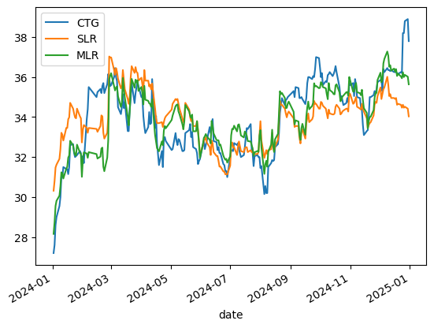

```python
start = '2024-01-01'
end = '2025-01-01'

closes = get_prices('CTG', 'VCB', 'FPT', 'VIC', 'SSI', 'VNINDEX', start_date=start, end_date=end).dropna()

x1 = closes['VCB']
x2 = closes['FPT']
x3 = closes['VIC']
x4 = closes['SSI']
y = closes['CTG']

# Build a linear model using only x1 to explain y
slr = regression.linear_model.OLS(y, sm.add_constant(x1)).fit()
slr_prediction = slr.params.iloc[0] + slr.params.iloc[1]*x1

# Run multiple linear regression using x1, x2, x3, x4 to explain y
mlr = regression.linear_model.OLS(y, sm.add_constant(np.column_stack((x1,x2,x3,x4)))).fit()
mlr_prediction = mlr.params.iloc[0] + mlr.params.iloc[1]*x1 + mlr.params.iloc[2]*x2 + mlr.params.iloc[3]*x3 + mlr.params.iloc[4]*x4

# Compute adjusted R-squared for the two different models
print('SLR R-squared:', slr.rsquared_adj)
print('MLR R-squared:', mlr.rsquared_adj)

# Plot y along with the two different predictions
y.plot()
slr_prediction.plot()
mlr_prediction.plot()
plt.legend(['CTG', 'SLR', 'MLR']);
```

Chúng ta có thể điều chỉnh mô hình với nhiều biến hơn một cách chính xác hơn theo dữ liệu. Lưu ý rằng mặc dù R-squared điều chỉnh phạt chúng ta vì sử dụng nhiều biến hơn, nhưng số lượng mẫu ở đây quá lớn nên sự điều chỉnh là rất nhỏ. Hãy xem điều gì xảy ra nếu chúng ta sử dụng các mô hình tuyến tính giống nhau để dự đoán giá của CTG trong ba tháng tới:

```
SLR R-squared: -6.041184806295779
MLR R-squared: -4.590453964826454
```

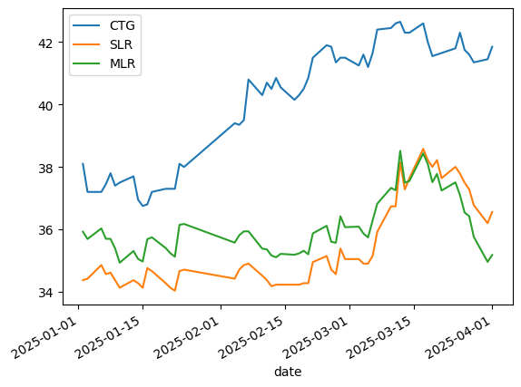

```python
start = '2025-01-01'
end = '2025-04-01'

closes = get_prices('CTG', 'VCB', 'FPT', 'VIC', 'SSI', 'VNINDEX', start_date=start, end_date=end).dropna()

x1 = closes['VCB']
x2 = closes['FPT']
x3 = closes['VIC']
x4 = closes['SSI']
y = closes['CTG']

# Extend our model from before to the new time period
slr_prediction2 = slr.params.iloc[0] + slr.params.iloc[1]*x1
mlr_prediction2 = mlr.params.iloc[0] + mlr.params.iloc[1]*x1 + mlr.params.iloc[2]*x2 + mlr.params.iloc[3]*x3 + mlr.params.iloc[4]*x4

# Compute adjusted R-squared over the extended time period
adj = float(len(y) - 1)/(len(y) - 5) # Compute adjustment factor
SST = sum((y - np.mean(y))**2)
SSRs = sum((slr_prediction2 - y)**2)
print('SLR R-squared:', 1 - adj*SSRs/SST)
SSRm = sum((mlr_prediction2 - y)**2)
print('MLR R-squared:', 1 - adj*SSRm/SST)

# Plot y along with the two different predictions
y.plot()
slr_prediction2.plot()
mlr_prediction2.plot()
plt.legend(['CTG', 'SLR', 'MLR']);
```

## Lỗi trong các biến độc lập

Nếu chúng ta sử dụng chỉ số hoặc ngày tháng làm các biến độc lập, chúng sẽ không có lỗi. Tuy nhiên, khi chúng ta muốn sử dụng giá trị của một cổ phiếu $X_t$ làm biến độc lập, chúng ta chỉ có thể đo giá, và giá này thường có nhiều biến động ngẫu nhiên nhỏ. Do đó, chúng ta thực sự quan sát $Z_t = X_t + u_t$ với một lỗi $u_t$. Mô hình của chúng ta là $$ Y_t = b_0 + b_1 X_t + \epsilon_t $$

tức là, một biến nào đó có mối quan hệ tuyến tính với giá trị của một cổ phiếu. Nhưng vì chúng ta chỉ biết giá trị của $Z_t$, chúng ta sẽ sử dụng mô hình $$ Y_t = b_0 + b_1 Z_t + (-b_1u_t + \epsilon_t) $$

Nếu $u_t$ không có tương quan với $X_t$, thì nó sẽ có tương quan với $Z_t$, và do đó, thành phần lỗi $-b_1u_t + \epsilon_t$ sẽ có tương quan với biến độc lập $Z_t$. Hậu quả là, các hệ số sẽ bị thiên lệch và không nhất quán. Cụ thể, $b_1$ sẽ bị thiên lệch theo hướng giảm.

## Dạng hàm không chính xác

Sau khi chúng ta chọn các biến mà chúng ta muốn đưa vào, chúng ta cần xác định một hình dạng cho hàm. Mặc dù một hồi quy yêu cầu hàm phải tuyến tính theo các hệ số, chúng ta có thể thao tác các biến để đạt được các loại hàm khác nhau. Ví dụ, mô hình $Y_i = b_0 + b_1 X_i^2 + \epsilon_i$ cho một mối quan hệ bậc hai giữa $X$ và $Y$, trong khi mô hình log-linear $\ln Y_i = b_0 + b_1 X_i + \epsilon_i$ cho một mối quan hệ hàm mũ. Nói chung, chúng ta chọn dạng hàm dựa trên kỳ vọng của chúng ta về mối quan hệ: ví dụ, một mô hình log-linear là tốt khi chúng ta kỳ vọng *tốc độ tăng trưởng* của $Y$ liên quan đến $X$.

Nếu chọn dạng hàm sai, chúng ta có thể không đạt được một sự phù hợp tốt. Thực tế, mô hình có thể dẫn đến những kết luận vô lý. Ví dụ, nếu chúng ta sử dụng một mô hình tuyến tính trong khi một mô hình logarit sẽ hợp lý hơn, chúng ta có thể dự đoán rằng số lượng công ty trong một loại nhất định trở nên âm thay vì gần bằng không.

Chúng ta cũng cần cẩn thận không chọn một dạng hàm chức năng quá khớp với dữ liệu. Việc sử dụng tùy tiện các đa thức bậc cao dẫn đến việc quá khớp vì chúng có nhiều bậc tự do hơn. Một vấn đề khác là khai thác dữ liệu: nếu chúng ta thử nhiều mô hình khác nhau cho đến khi tìm ra mô hình trông tốt nhất, chúng ta đang quá khớp với mẫu với cái giá là khả năng dự đoán trong tương lai.

## Tập hợp các quần thể khác nhau

Nếu chúng ta cố gắng sử dụng một mô hình cho hai quần thể mà mô hình riêng biệt sẽ phù hợp hơn, chúng ta sẽ nhận được những kết quả dễ gây hiểu lầm theo một hướng nào đó. Ví dụ, nếu chúng ta trộn lẫn dữ liệu về mức lương của nam giới và nữ giới, có thể sẽ có quá nhiều sự phân tán để tìm ra một mô hình phù hợp tốt, như trong ví dụ giả định dưới đây.

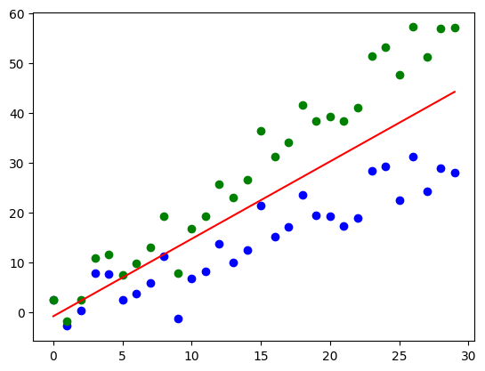

```python
# Generate two artificial samples and pool them
sample1 = np.arange(30) + 4*np.random.randn(30)
sample2 = sample1 + np.arange(30)
pool = np.hstack((sample1, sample2))

# Run a regression on the pooled data, with the independent variable being the original indices
model = regression.linear_model.OLS(pool, sm.add_constant(np.hstack((np.arange(30),np.arange(30))))).fit()

# Plot the two samples along with the regression line
plt.scatter(np.arange(30), sample1, color='b')
plt.scatter(np.arange(30), sample2, color='g')
plt.plot(model.params[0] + model.params[1]*np.arange(30), color='r');
```

Rõ ràng rằng việc sử dụng hai mô hình riêng biệt cho hai tập dữ liệu sẽ phù hợp hơn. Lưu ý rằng, như đã nói ở trên, điều này có thể dẫn đến các vi phạm giả định như heteroskedasticity và các lỗi không phân phối chuẩn.

## Chuỗi thời gian không ổn định

Một quá trình tĩnh là một quá trình mà phân phối xác suất chung của nó không thay đổi theo thời gian. Cụ thể, giá trị trung bình và phương sai của nó là hằng số theo thời gian. Khi chúng ta áp dụng các mô hình hồi quy cho chuỗi thời gian, chúng ta phải đưa ra giả định bổ sung rằng chúng là ổn định. Nếu không, các thống kê t của các tham số sẽ không hợp lệ.

Một bước đi ngẫu nhiên là một quá trình mà ước lượng tốt nhất cho giá trị tiếp theo là giá trị trước đó; nếu bạn đi bộ ngẫu nhiên, vị trí của bạn sau mỗi bước sẽ nằm gần vị trí của bạn trước bước nhưng theo hướng không thể đoán trước. Một cách chính thức, một bước đi một chiều như vậy được mô tả bởi phương trình $$ x_t = x_{t-1} + \epsilon_t $$

trong đó sai số $\epsilon_t$ là đồng phương sai, có giá trị trung bình bằng không, và không có tự tương quan. Ví dụ, tỷ giá hối đoái thường được giả định là các bước đi ngẫu nhiên. Các bước đi ngẫu nhiên có phương sai tăng theo thời gian và do đó không ổn định. Chúng dễ bị ảnh hưởng bởi các kết quả giả mạo, và hai bước đi ngẫu nhiên sẽ xuất hiện có tương quan cao rất thường xuyên. Hãy thử chạy đoạn code dưới đây nhiều lần:

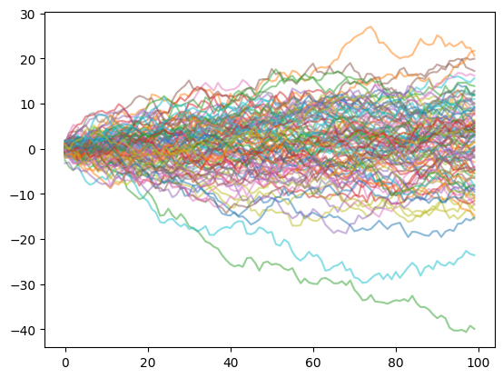

```python
# Generate normally distributed errors
randos = [np.random.randn(100) for i in range(100)]
y = np.random.randn(100)
# Generate random walks
randows = [[sum(rando[:i+1]) for i in range(100)] for rando in randos]
yw = [sum(y[:i+1]) for i in range(100)]

for i in range(100):
    plt.plot(randows[i], alpha=0.5)
```

```
Linearly related walks out of 100: 21
```

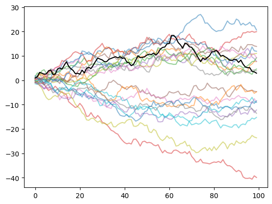

```python
# Compute R-squared of linear regression for each element of randows with yw
rs = [regression.linear_model.OLS(yw, x).fit().rsquared for x in randows]

# Plot and count the random walks that have R-squared with yw > .8
rcount = 0
for i in range(100):
    if rs[i] > .8:
        rcount += 1
        plt.plot(randows[i], alpha=0.5)
print('Linearly related walks out of 100:', rcount)

# Plot yw
plt.plot(yw, color='k');
```

Lý do cho hai nhánh trên là vì một phép hồi quy tuyến tính hoạt động tốt cho cả các biến có mối tương quan dương và âm.

Kết quả thậm chí còn cực đoan hơn nếu chúng ta xem xét các bước đi ngẫu nhiên có mối tương quan đáng kể, theo giá trị p của các hệ số tương quan của chúng:

```
Significantly correlated walks out of 100: 72
```

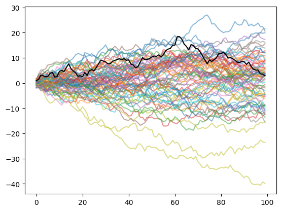

```python
from scipy.stats import pearsonr

# Compute correlation coefficients (Pearson r) and record their p-values
ps = [pearsonr(yw, x)[1] for x in randows]

# Plot and count the random walks that have p-value of correlation with yw < 0.05
pcount = 0
for i in range(100):
    if ps[i] < .05:
        pcount += 1
        plt.plot(randows[i], alpha=0.5)
print('Significantly correlated walks out of 100:', pcount)

# Plot yw
plt.plot(yw, color='k');
```

Bởi vì xác suất cao của các kết quả giả mạo, các thống kê phù hợp mà chúng ta tính toán khi hồi quy trên các bước ngẫu nhiên là không hợp lệ. Hơn nữa, các ước lượng tham số là không nhất quán.

Chúng ta có thể phát hiện các bước ngẫu nhiên và chuỗi thời gian liên quan (chẳng hạn như một bước ngẫu nhiên có độ trôi) bằng cách kiểm tra sự hiện diện của một *nghiệm đơn vị* trong chuỗi thời gian; tức là, liệu nó có xuất hiện theo phương trình $x_t = x_{t-1} + \epsilon_t$ hay không. Một phương pháp là sử dụng kiểm định Dickey-Fuller:

```python
from statsmodels.tsa.stattools import adfuller

# Compute the p-value of the Dickey-Fuller statistic to test the null hypothesis that yw has a unit root
print(adfuller(yw)[1])
```

```
0.5108597290301998
```

Do đó, chúng ta không thể bác bỏ giả thuyết rằng `yw` có một nghiệm đơn vị (như chúng ta biết nó có, theo cấu trúc). Nếu chúng ta biết rằng một chuỗi thời gian có một nghiệm đơn vị và chúng ta vẫn muốn phân tích nó, chúng ta có thể mô hình hóa chuỗi sai khác đầu tiên $y_t = x_t - x_{t-1}$ nếu nó là tĩnh, và sử dụng nó để dự đoán các giá trị tương lai của $x$. Chúng ta cũng có thể sử dụng hồi quy nếu cả biến phụ thuộc và biến độc lập đều là các chuỗi thời gian có nghiệm đơn vị và hai biến này có đồng liên kết.

## Tham khảo

- "Quantitative Investment Analysis", by DeFusco, McLeavey, Pinto, and Runkle

*Lưu ý: Tài liệu này mang tính chất chia sẻ kiến thức khoa học dữ liệu. Các mã chứng khoán xuất hiện trong tài liệu chỉ mang tính chất minh hoạ, không khuyến nghị đầu tư. Chúng tôi không chịu trách nhiệm trước mọi rủi ro nào do sử dụng tài liệu này.*